# Nback Notebook

TODO: deal with first trial for oneback and first two trials for twoback -current solution is to eliminate trials that are accurate with a RT of 0.

# NBACK PRE DATA ANALYSIS

## Data Prep

Getting the Data ready for analysis Defaults: R uses dummy coding as it’s default. In this sample, the control group and the 1-Back will be the dummy variables in the analysis. So all Estimates are relative to these dummy variables

### Load Requisite R Packages

note: some of these may not actually be used.

```r
library(ggplot2)
library(lme4)
library(languageR)
library(lmerTest)
library(influence.ME)
library(plyr) # magic
library(scales) #for making percents on the y-axis of graphs
```

### Read in the dataset (in current directory)

```r
Nback_data = read.table("Nback_R_format.csv", header = TRUE, sep = ",")
```

### Omit missing data (e.g. from practice trials)

```r
Nback_data[Nback_data==""] <- NA
#my current solution to deal with the first trials of one-back and twoback
Nback_data$RT[Nback_data$RT==0 & Nback_data$ACC==1] <- NA
Nback_data = na.omit(Nback_data)
head(Nback_data, n = 20)
```

```
##    subject        group session stimtype ACC  RT
## 15       5 Experimental       1 singleBl   1 686
## 16       5 Experimental       1 singleBl   1 731
## 17       5 Experimental       1 singleBl   1 439
## 18       5 Experimental       1 singleBl   1 836
## 19       5 Experimental       1 singleBl   1 769
## 20       5 Experimental       1 singleBl   1 717
## 21       5 Experimental       1 singleBl   1 666
## 22       5 Experimental       1 singleBl   1 823
## 23       5 Experimental       1 singleBl   1 610
## 24       5 Experimental       1 singleBl   1 415
## 25       5 Experimental       1 singleBl   1 763
## 26       5 Experimental       1 singleBl   1 664
## 27       5 Experimental       1 singleBl   1 773
## 28       5 Experimental       1 singleBl   1 769
## 29       5 Experimental       1 singleBl   1 798
## 30       5 Experimental       1 singleBl   1 731
## 31       5 Experimental       1 singleBl   1 615
## 32       5 Experimental       1 singleBl   1 628
## 33       5 Experimental       1 singleBl   1 800
## 35       5 Experimental       1 singleBl   1 723
```

### Omit the Undefined group from the data and specify group as a factor

```r
Nback_data <- subset(Nback_data,group=="Control" | group=="Experimental")
Nback_data$group <- factor(Nback_data$group)
summary(Nback_data)
```

```
##     subject               group          session         stimtype
##  Min.   :  5.0   Control     :11672   Min.   :1.00           :    0
##  1st Qu.: 45.0   Experimental:10385   1st Qu.:1.00   singleBl:11321
##  Median : 98.0                        Median :1.00   twoBlock:10736
##  Mean   :104.4                        Mean   :1.47
##  3rd Qu.:166.0                        3rd Qu.:2.00
##  Max.   :209.0                        Max.   :2.00
##       ACC               RT
##  Min.   :0.0000   Min.   :   0.0
##  1st Qu.:1.0000   1st Qu.: 650.0
##  Median :1.0000   Median : 837.0
##  Mean   :0.9079   Mean   : 888.1
##  3rd Qu.:1.0000   3rd Qu.:1102.0
##  Max.   :1.0000   Max.   :1999.0
```

```r
contrasts(Nback_data$group)
```

```
##              Experimental
## Control                 0
## Experimental            1
```

### Omit the Undefined stimtype and specify stimtype as a factor

```r
Nback_data <- subset(Nback_data,stimtype=="singleBl" | stimtype=="twoBlock")
Nback_data$stimtype <- factor(Nback_data$stimtype)
summary(Nback_data)
```

```
##     subject               group          session         stimtype
##  Min.   :  5.0   Control     :11672   Min.   :1.00   singleBl:11321
##  1st Qu.: 45.0   Experimental:10385   1st Qu.:1.00   twoBlock:10736
##  Median : 98.0                        Median :1.00
##  Mean   :104.4                        Mean   :1.47
##  3rd Qu.:166.0                        3rd Qu.:2.00
##  Max.   :209.0                        Max.   :2.00
##       ACC               RT
##  Min.   :0.0000   Min.   :   0.0
##  1st Qu.:1.0000   1st Qu.: 650.0
##  Median :1.0000   Median : 837.0
##  Mean   :0.9079   Mean   : 888.1
##  3rd Qu.:1.0000   3rd Qu.:1102.0
##  Max.   :1.0000   Max.   :1999.0
```

```r
contrasts(Nback_data$stimtype)
```

```
##          twoBlock
## singleBl        0
## twoBlock        1
```

### Isolate the session to the first session

```r
#Isolate Pre data
Nback_data_pre <- subset(Nback_data, session==1)
#Specify Pre session as a factor.
Nback_data_pre$session <- factor(Nback_data_pre$session)
summary(Nback_data_pre)
```

```
##     subject               group      session       stimtype
##  Min.   :  5.0   Control     :6298   1:11684   singleBl:5997
##  1st Qu.: 45.0   Experimental:5386             twoBlock:5687
##  Median : 98.0
##  Mean   :105.4
##  3rd Qu.:172.0
##  Max.   :209.0
##       ACC               RT
##  Min.   :0.0000   Min.   :   0.0
##  1st Qu.:1.0000   1st Qu.: 681.0
##  Median :1.0000   Median : 871.0
##  Mean   :0.8956   Mean   : 915.1
##  3rd Qu.:1.0000   3rd Qu.:1142.0
##  Max.   :1.0000   Max.   :1999.0
```

### specify subject as a factor

```r
Nback_data_pre$subject <- as.factor(Nback_data_pre$subject)
summary(Nback_data_pre)
```

```
##     subject               group      session       stimtype
##  56     :  197   Control     :6298   1:11684   singleBl:5997
##  66     :  188   Experimental:5386             twoBlock:5687
##  159    :  188
##  182    :  188
##  74     :  187
##  140    :  187
##  (Other):10549
##       ACC               RT
##  Min.   :0.0000   Min.   :   0.0
##  1st Qu.:1.0000   1st Qu.: 681.0
##  Median :1.0000   Median : 871.0
##  Mean   :0.8956   Mean   : 915.1
##  3rd Qu.:1.0000   3rd Qu.:1142.0
##  Max.   :1.0000   Max.   :1999.0
##
```

## NBack Accuracy Analysis

### Print out binary accuracy data for each subject for each group

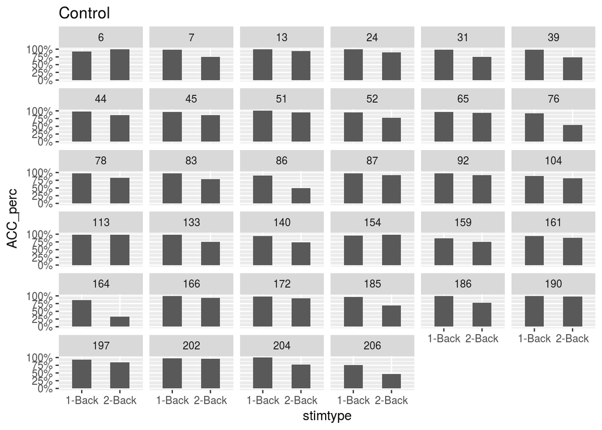

```r
#Control Group Data
Nback_data_pre_control <- subset(Nback_data_pre, group=="Control")
#change binary data to a percent
Nback_data_pre_control_percent <- ddply(Nback_data_pre_control, .(stimtype, subject), summarize, ACC_perc = mean(ACC))

#Experimental Group Data
Nback_data_pre_experimental <- subset(Nback_data_pre, group=="Experimental")
#change binary data to a percent
Nback_data_pre_experimental_percent <- ddply(Nback_data_pre_experimental, .(stimtype, subject), summarize, ACC_perc = mean(ACC))

ggplot(data = Nback_data_pre_control_percent, aes( x = stimtype, y = ACC_perc)) + geom_bar(stat = "identity", width = 0.5) + facet_wrap(~subject) + scale_y_continuous(labels=percent) + scale_x_discrete(labels=c("1-Back","2-Back")) + ggtitle("Control")
```

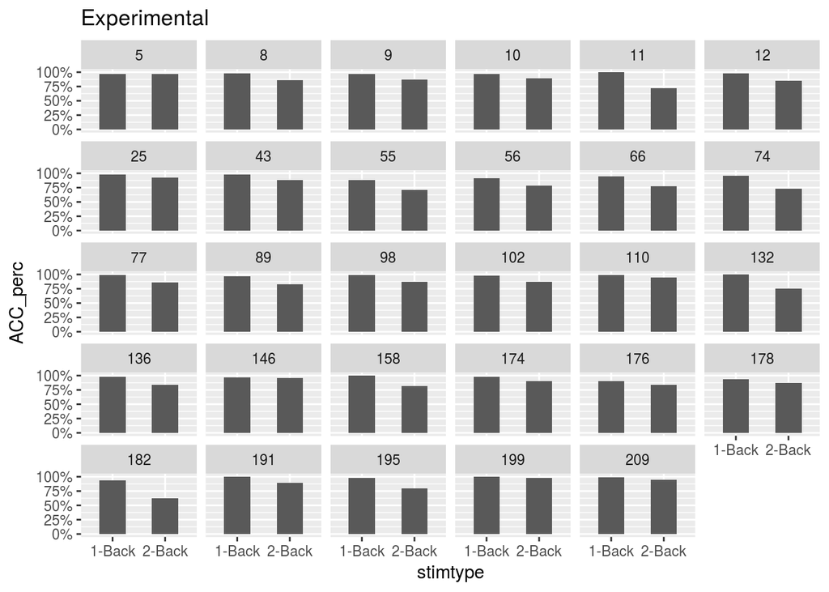

```r
ggplot(data = Nback_data_pre_experimental_percent, aes( x = stimtype, y = ACC_perc)) + geom_bar(stat = "identity", width = 0.5) + facet_wrap(~subject) + scale_y_continuous(labels=percent) +  scale_x_discrete(labels=c("1-Back","2-Back")) + ggtitle("Experimental")
```

**Conclusion**: sub164 has low accuracy for the 2-back sub86 has low accuracy for the 2-back

### Model Accuracy (Logit)

Testing for main effects of and interactions between group (Exp and Con) and stimtype (1-Back and 2-Back) using random intercepts for subjects to account for variability between subjects. Since the response variable (ACC) contains 1’s and 0’s, I’m using a Logistic model for the data.

```r
Nback_ACC_model<-glmer(ACC ~ group*stimtype + (1|subject), family=binomial, data=Nback_data_pre, verbose=TRUE)
```

[output not shown]

```r
summary(Nback_ACC_model)
```

```
## Generalized linear mixed model fit by maximum likelihood (Laplace
##   Approximation) [glmerMod]
##  Family: binomial  ( logit )
## Formula: ACC ~ group * stimtype + (1 | subject)
##    Data: Nback_data_pre
##
##      AIC      BIC   logLik deviance df.resid
##   6730.6   6767.4  -3360.3   6720.6    11679
##
## Scaled residuals:
##      Min       1Q   Median       3Q      Max
## -10.7031   0.1350   0.2225   0.3740   1.1772
##
## Random effects:
##  Groups  Name        Variance Std.Dev.
##  subject (Intercept) 0.6289   0.7931
## Number of obs: 11684, groups:  subject, 63
##
## Fixed effects:
##                                    Estimate Std. Error z value Pr(>|z|)
## (Intercept)                         3.42057    0.16506  20.723   <2e-16
## groupExperimental                   0.21284    0.24806   0.858    0.391
## stimtypetwoBlock                   -1.74331    0.10026 -17.387   <2e-16
## groupExperimental:stimtypetwoBlock -0.05043    0.15874  -0.318    0.751
##
## (Intercept)                        ***
## groupExperimental
## stimtypetwoBlock                   ***
## groupExperimental:stimtypetwoBlock
## ---
## Signif. codes:  0 '***' 0.001 '**' 0.01 '*' 0.05 '.' 0.1 ' ' 1
##
## Correlation of Fixed Effects:
##             (Intr) grpExp stmtyB
## grpExprmntl -0.662
## stmtyptwBlc -0.478  0.317
## grpExprmn:B  0.301 -0.511 -0.631
```

**Conclusion**: 2-Back is significantly less accurate than 1-Back (as expected), but no group effect or groupxstimtype interaction (as expected)

## NBack Reaction Time Analysis

### Format RT data

(subset for RTs when they are accurate, greater than 200ms, and less than 2000 ms) See how many observations are lost when we subset the data

```r
#all observations
print("All Data")
```

```
## [1] "All Data"
```

```r
All_data <- length(Nback_data_pre$RT)
summary(Nback_data_pre)
```

```
##     subject               group      session       stimtype
##  56     :  197   Control     :6298   1:11684   singleBl:5997
##  66     :  188   Experimental:5386             twoBlock:5687
##  159    :  188
##  182    :  188
##  74     :  187
##  140    :  187
##  (Other):10549
##       ACC               RT
##  Min.   :0.0000   Min.   :   0.0
##  1st Qu.:1.0000   1st Qu.: 681.0
##  Median :1.0000   Median : 871.0
##  Mean   :0.8956   Mean   : 915.1
##  3rd Qu.:1.0000   3rd Qu.:1142.0
##  Max.   :1.0000   Max.   :1999.0
##
```

```r
#remove innacurate responses
print("Removed innacurate trials (from all data dataframe)")
```

```
## [1] "Removed innacurate trials (from all data dataframe)"
```

```r
Nback_data_pre_RT <- subset(Nback_data_pre, ACC==1)
ACC_filt_data <- length(Nback_data_pre_RT$RT)
summary(Nback_data_pre_RT)
```

```
##     subject              group      session       stimtype         ACC
##  199    : 183   Control     :5566   1:10464   singleBl:5765   Min.   :1
##  190    : 182   Experimental:4898             twoBlock:4699   1st Qu.:1
##  113    : 181                                                 Median :1
##  13     : 180                                                 Mean   :1
##  51     : 180                                                 3rd Qu.:1
##  154    : 180                                                 Max.   :1
##  (Other):9378
##        RT
##  Min.   :   9.0
##  1st Qu.: 713.0
##  Median : 886.0
##  Mean   : 961.5
##  3rd Qu.:1147.0
##  Max.   :1999.0
##
```

```r
#remove short and long RTs
print("Removed slow and fast RTs")
```

```
## [1] "Removed slow and fast RTs"
```

```r
Nback_data_pre_RT <- subset(Nback_data_pre_RT, RT>200 & RT<2000)
filt_data <- length(Nback_data_pre_RT$RT)
summary(Nback_data_pre_RT)
```

```
##     subject              group      session       stimtype         ACC
##  199    : 183   Control     :5559   1:10455   singleBl:5763   Min.   :1
##  113    : 181   Experimental:4896             twoBlock:4692   1st Qu.:1
##  190    : 181                                                 Median :1
##  13     : 180                                                 Mean   :1
##  51     : 180                                                 3rd Qu.:1
##  154    : 180                                                 Max.   :1
##  (Other):9370
##        RT
##  Min.   : 237.0
##  1st Qu.: 713.5
##  Median : 887.0
##  Mean   : 962.3
##  3rd Qu.:1148.0
##  Max.   :1999.0
##
```

```r
print("Percent Data Removed (from RT filtering)")
```

```
## [1] "Percent Data Removed (from RT filtering)"
```

```r
perc_data_rm <- (1 - (filt_data/ACC_filt_data))*100
perc_data_rm
```

```
## [1] 0.08600917
```

**Conclusion**: barely any RTs are removed, I’m not worried about this

### graph RT data

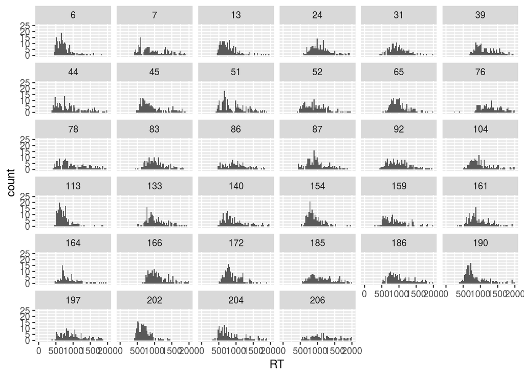

```r
#hist(subset(Nback_data_pre_RT, group=="Control")$RT,ylim=c(0,800))
#hist(subset(Nback_data_pre_RT, group=="Experimental")$RT,ylim=c(0,800))

Nback_data_pre_RT_control <- subset(Nback_data_pre_RT, group=="Control")

Nback_data_pre_RT_experimental <- subset(Nback_data_pre_RT, group=="Experimental")

#collapsing across stimtype (1-back and 2-back), not enough data to make a good histogram, and the graphs become too crowded if I include stimtype as a facet
RT_hist_control <- ggplot(data = Nback_data_pre_RT_control, aes(RT)) + geom_histogram(binwidth = 30) + facet_wrap(~subject) + scale_y_continuous(limits = c(0,25)) + scale_x_continuous(limits = c(0,2000))
print(RT_hist_control)
```

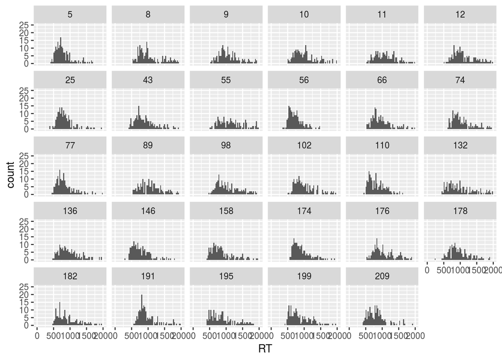

```r
RT_hist_experimental <- ggplot(data = Nback_data_pre_RT_experimental, aes(RT)) + geom_histogram(binwidth = 30) + facet_wrap(~subject) + scale_y_continuous(limits = c(0,25)) + scale_x_continuous(limits = c(0,2000))
print(RT_hist_experimental)
```

**Conclusion**: RT data shows classic right skew for almost all the participants, going to transform the RT data to make them normally distributed

### Log Transform RT data to make them normally distributed

```r
Nback_data_pre_RT$log_RT <- log(1/Nback_data_pre_RT$RT)
```

### Graph log_RT data

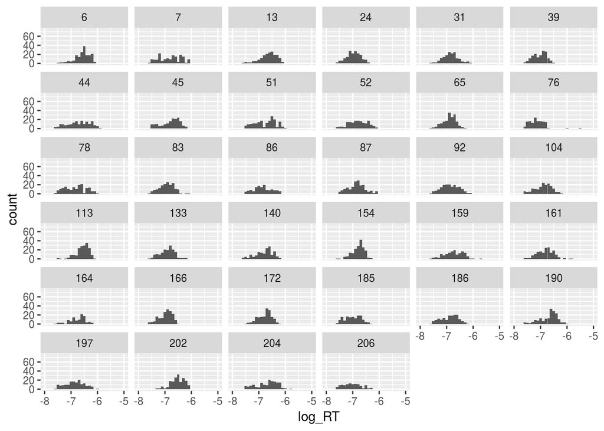

```r
Nback_data_pre_RT_control <- subset(Nback_data_pre_RT, group=="Control")

Nback_data_pre_RT_experimental <- subset(Nback_data_pre_RT, group=="Experimental")

#collapsing across stimtype (1-back and 2-back), not enough data to make a good histogram, and the graphs become too crowded if I include stimtype as a facet
RT_hist_control <- ggplot(data = Nback_data_pre_RT_control, aes(log_RT)) + geom_histogram(binwidth = .1) + facet_wrap(~subject) + scale_y_continuous(limits = c(0,75)) + scale_x_continuous(limits = c(-8,-5))
print(RT_hist_control)
```

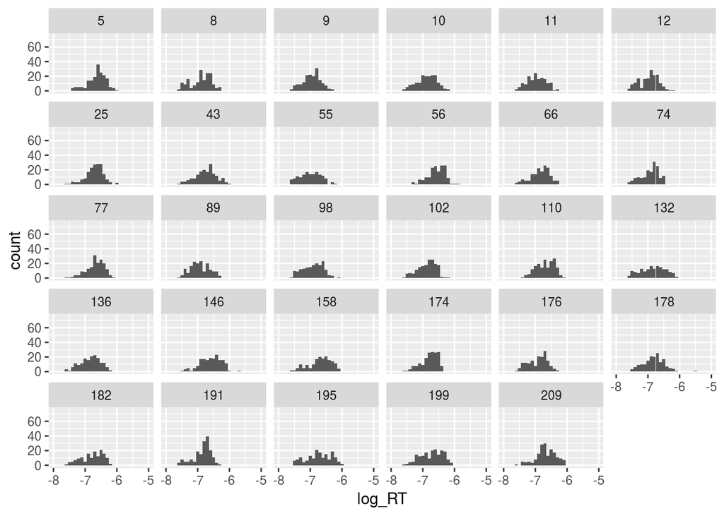

```r
RT_hist_experimental <- ggplot(data = Nback_data_pre_RT_experimental, aes(log_RT)) + geom_histogram(binwidth = .1) + facet_wrap(~subject) + scale_y_continuous(limits = c(0,75)) + scale_x_continuous(limits = c(-8,-5))
print(RT_hist_experimental)
```

**Conclusion**: The log transformed RT data looks more normally distributed. Going to use the log transformed RTs in the linear model

### Model log_RT (lmer)

Testing for main effects of and interactions between group (Exp and Con) and stimtype (1-Back and 2-Back) using random intercepts for subjects to account for variability between subjects. The response variable is a continuous, normally distributed variable (Reaction Time), so I am using a regular linear model with random subject intercepts (account for mean differences)

```r
Nback_RT_model <- lmer(log_RT ~ group*stimtype + (1|subject), data = Nback_data_pre_RT)
summary(Nback_RT_model)
```

```
## Linear mixed model fit by REML t-tests use Satterthwaite approximations
##   to degrees of freedom [lmerMod]
## Formula: log_RT ~ group * stimtype + (1 | subject)
##    Data: Nback_data_pre_RT
##
## REML criterion at convergence: 2847.3
##
## Scaled residuals:
##     Min      1Q  Median      3Q     Max
## -3.8028 -0.6420  0.0557  0.6552  6.5337
##
## Random effects:
##  Groups   Name        Variance Std.Dev.
##  subject  (Intercept) 0.01796  0.1340
##  Residual             0.07502  0.2739
## Number of obs: 10455, groups:  subject, 63
##
## Fixed effects:
##                                      Estimate Std. Error         df
## (Intercept)                        -6.687e+00  2.351e-02  6.300e+01
## groupExperimental                   1.629e-02  3.464e-02  6.300e+01
## stimtypetwoBlock                   -3.078e-01  7.420e-03  1.040e+04
## groupExperimental:stimtypetwoBlock  2.586e-03  1.082e-02  1.039e+04
##                                     t value Pr(>|t|)
## (Intercept)                        -284.481   <2e-16 ***
## groupExperimental                     0.470    0.640
## stimtypetwoBlock                    -41.485   <2e-16 ***
## groupExperimental:stimtypetwoBlock    0.239    0.811
## ---
## Signif. codes:  0 '***' 0.001 '**' 0.01 '*' 0.05 '.' 0.1 ' ' 1
##
## Correlation of Fixed Effects:
##             (Intr) grpExp stmtyB
## grpExprmntl -0.679
## stmtyptwBlc -0.139  0.094
## grpExprmn:B  0.095 -0.139 -0.686
```

**Conclusion**: No group differences (as expected) and the 2-Back is slower (I think) than the 1-Back (as expected)

## Conclusions

Participants performed the Nback as expected with no differences between groups. A couple participants (sub86,sub164) have low accuracy in the 2-Back